# Risk Factor Analysis

## Outcome Variable

**Outcome Variable:** stunted

## Predictor Variables

**Intervention Variable:** earlybf

**Adjustment Set:**

- arm
- sex
- W_mage
- meducyrs
- feducyrs
- hhwealth_quart
- hfoodsec
- W_mhtcm
- vagbrth
- W_gagebrth
- W_birthwt
- W_birthlen
- W_nrooms
- W_nchldlt5
- brthmon
- W_parity
- impfloor
- impsan
- safeh20
- delta_W_mage
- delta_meducyrs
- delta_feducyrs
- delta_hhwealth_quart
- delta_hfoodsec
- delta_W_mhtcm
- delta_vagbrth
- delta_W_gagebrth
- delta_W_birthwt
- delta_W_birthlen
- delta_W_nrooms
- delta_W_nchldlt5
- delta_brthmon
- delta_W_parity
- delta_impfloor
- delta_impsan
- delta_safeh20

## Stratifying Variables

The analysis was stratified on these variable(s):

- agecat
- studyid
- country

## Data Summary

| agecat | studyid | country | earlybf | stunted | n_cell | n |
| --- | --- | --- | --- | --- | --- | --- |
| Birth | ki0047075b-MAL-ED | BANGLADESH | 0 | 0 | 75 | 256 |
| Birth | ki0047075b-MAL-ED | BANGLADESH | 0 | 1 | 22 | 256 |
| Birth | ki0047075b-MAL-ED | BANGLADESH | 1 | 0 | 134 | 256 |
| Birth | ki0047075b-MAL-ED | BANGLADESH | 1 | 1 | 25 | 256 |
| Birth | ki0047075b-MAL-ED | BRAZIL | 0 | 0 | 94 | 191 |
| Birth | ki0047075b-MAL-ED | BRAZIL | 0 | 1 | 14 | 191 |
| Birth | ki0047075b-MAL-ED | BRAZIL | 1 | 0 | 76 | 191 |
| Birth | ki0047075b-MAL-ED | BRAZIL | 1 | 1 | 7 | 191 |
| Birth | ki0047075b-MAL-ED | INDIA | 0 | 0 | 66 | 205 |
| Birth | ki0047075b-MAL-ED | INDIA | 0 | 1 | 15 | 205 |
| Birth | ki0047075b-MAL-ED | INDIA | 1 | 0 | 106 | 205 |
| Birth | ki0047075b-MAL-ED | INDIA | 1 | 1 | 18 | 205 |
| Birth | ki0047075b-MAL-ED | NEPAL | 0 | 0 | 83 | 173 |
| Birth | ki0047075b-MAL-ED | NEPAL | 0 | 1 | 11 | 173 |
| Birth | ki0047075b-MAL-ED | NEPAL | 1 | 0 | 72 | 173 |
| Birth | ki0047075b-MAL-ED | NEPAL | 1 | 1 | 7 | 173 |
| Birth | ki0047075b-MAL-ED | PERU | 0 | 0 | 61 | 287 |
| Birth | ki0047075b-MAL-ED | PERU | 0 | 1 | 12 | 287 |
| Birth | ki0047075b-MAL-ED | PERU | 1 | 0 | 192 | 287 |
| Birth | ki0047075b-MAL-ED | PERU | 1 | 1 | 22 | 287 |
| Birth | ki0047075b-MAL-ED | SOUTH AFRICA | 0 | 0 | 78 | 247 |
| Birth | ki0047075b-MAL-ED | SOUTH AFRICA | 0 | 1 | 14 | 247 |
| Birth | ki0047075b-MAL-ED | SOUTH AFRICA | 1 | 0 | 143 | 247 |
| Birth | ki0047075b-MAL-ED | SOUTH AFRICA | 1 | 1 | 12 | 247 |
| Birth | ki0047075b-MAL-ED | TANZANIA, UNITED REPUBLIC OF | 0 | 0 | 9 | 123 |
| Birth | ki0047075b-MAL-ED | TANZANIA, UNITED REPUBLIC OF | 0 | 1 | 3 | 123 |
| Birth | ki0047075b-MAL-ED | TANZANIA, UNITED REPUBLIC OF | 1 | 0 | 96 | 123 |
| Birth | ki0047075b-MAL-ED | TANZANIA, UNITED REPUBLIC OF | 1 | 1 | 15 | 123 |
| Birth | ki1000109-EE | PAKISTAN | 0 | 0 | 2 | 4 |
| Birth | ki1000109-EE | PAKISTAN | 0 | 1 | 0 | 4 |

[output cut: 126 more lines]

The following strata were considered:

- agecat: 24 months, studyid: ki0047075b-MAL-ED, country: BANGLADESH
- agecat: 24 months, studyid: ki0047075b-MAL-ED, country: BRAZIL
- agecat: 24 months, studyid: ki0047075b-MAL-ED, country: INDIA
- agecat: 24 months, studyid: ki0047075b-MAL-ED, country: NEPAL
- agecat: 24 months, studyid: ki0047075b-MAL-ED, country: PERU
- agecat: 24 months, studyid: ki0047075b-MAL-ED, country: SOUTH AFRICA
- agecat: 24 months, studyid: ki0047075b-MAL-ED, country: TANZANIA, UNITED REPUBLIC OF
- agecat: 24 months, studyid: ki1017093c-NIH-Crypto, country: BANGLADESH
- agecat: 24 months, studyid: ki1113344-GMS-Nepal, country: NEPAL
- agecat: 24 months, studyid: ki1126311-ZVITAMBO, country: ZIMBABWE
- agecat: 24 months, studyid: kiGH5241-JiVitA-3, country: BANGLADESH
- agecat: 24 months, studyid: kiGH5241-JiVitA-4, country: BANGLADESH
- agecat: 6 months, studyid: ki0047075b-MAL-ED, country: BANGLADESH
- agecat: 6 months, studyid: ki0047075b-MAL-ED, country: BRAZIL
- agecat: 6 months, studyid: ki0047075b-MAL-ED, country: INDIA
- agecat: 6 months, studyid: ki0047075b-MAL-ED, country: NEPAL
- agecat: 6 months, studyid: ki0047075b-MAL-ED, country: PERU
- agecat: 6 months, studyid: ki0047075b-MAL-ED, country: SOUTH AFRICA
- agecat: 6 months, studyid: ki0047075b-MAL-ED, country: TANZANIA, UNITED REPUBLIC OF
- agecat: 6 months, studyid: ki1000109-EE, country: PAKISTAN
- agecat: 6 months, studyid: ki1000304b-SAS-CompFeed, country: INDIA
- agecat: 6 months, studyid: ki1017093c-NIH-Crypto, country: BANGLADESH
- agecat: 6 months, studyid: ki1113344-GMS-Nepal, country: NEPAL
- agecat: 6 months, studyid: ki1126311-ZVITAMBO, country: ZIMBABWE
- agecat: 6 months, studyid: kiGH5241-JiVitA-3, country: BANGLADESH
- agecat: 6 months, studyid: kiGH5241-JiVitA-4, country: BANGLADESH
- agecat: Birth, studyid: ki0047075b-MAL-ED, country: BANGLADESH
- agecat: Birth, studyid: ki0047075b-MAL-ED, country: BRAZIL
- agecat: Birth, studyid: ki0047075b-MAL-ED, country: INDIA
- agecat: Birth, studyid: ki0047075b-MAL-ED, country: NEPAL
- agecat: Birth, studyid: ki0047075b-MAL-ED, country: PERU
- agecat: Birth, studyid: ki0047075b-MAL-ED, country: SOUTH AFRICA
- agecat: Birth, studyid: ki0047075b-MAL-ED, country: TANZANIA, UNITED REPUBLIC OF
- agecat: Birth, studyid: ki1000109-EE, country: PAKISTAN
- agecat: Birth, studyid: ki1000304b-SAS-CompFeed, country: INDIA
- agecat: Birth, studyid: ki1017093c-NIH-Crypto, country: BANGLADESH
- agecat: Birth, studyid: ki1126311-ZVITAMBO, country: ZIMBABWE
- agecat: Birth, studyid: kiGH5241-JiVitA-3, country: BANGLADESH
- agecat: Birth, studyid: kiGH5241-JiVitA-4, country: BANGLADESH

### Dropped Strata

Some strata were dropped due to rare outcomes:

- agecat: Birth, studyid: ki0047075b-MAL-ED, country: TANZANIA, UNITED REPUBLIC OF
- agecat: Birth, studyid: ki1000109-EE, country: PAKISTAN
- agecat: Birth, studyid: ki1000304b-SAS-CompFeed, country: INDIA
- agecat: Birth, studyid: ki1017093c-NIH-Crypto, country: BANGLADESH
- agecat: 6 months, studyid: ki0047075b-MAL-ED, country: BRAZIL
- agecat: 6 months, studyid: ki0047075b-MAL-ED, country: NEPAL
- agecat: 24 months, studyid: ki0047075b-MAL-ED, country: BRAZIL
- agecat: 24 months, studyid: kiGH5241-JiVitA-3, country: BANGLADESH

## Methods Detail

We’re interested in the causal parameters $E[Y_a]$ for all values of $a \in \mathcal{A}$. These parameters represent the mean outcome if, possibly contrary to fact, we intervened to set all units to have $A=a$. Under the randomization and positivity assumptions, these are identified by the statistical parameters $\psi_a=E_W[E_{Y|A,W}(Y|A=a,W)]$. In addition, we’re interested in the mean of $Y$, $E[Y]$ under no intervention (the observed mean). We will estimate these parameters by using SuperLearner to fit the relevant likelihood factors – $E_{Y|A,W}(Y|A=a,W)$ and $p(A=a|W)$, and then updating our likelihood fit using a joint TMLE.

For unadjusted analyses ($W=\{\}$), initial likelihoods were estimated using Lrnr_glm to estimate the simple $E(Y|A)$ and Lrnr_mean to estimate $p(A)$. For adjusted analyses, a small library containing Lrnr_glmnet, Lrnr_xgboost, and Lrnr_mean was used.

Having estimated these parameters, we will then use the delta method to estimate relative risks and attributable risks relative to a prespecified baseline level of $A$.

# Results Detail

## Results Plots

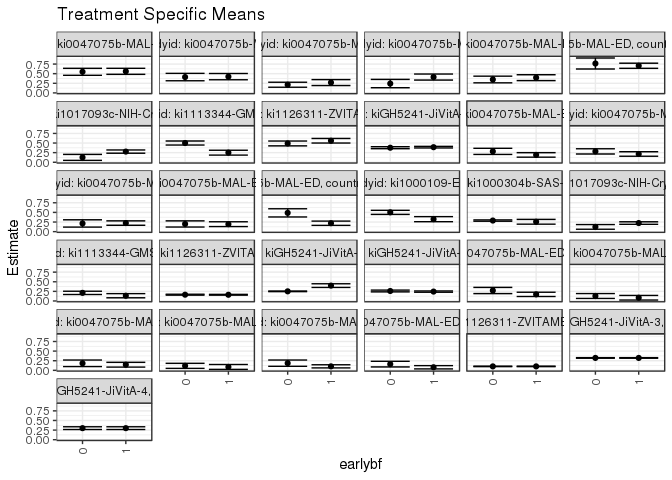

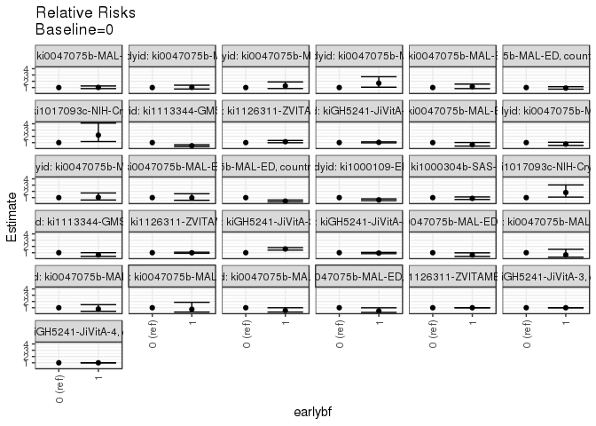

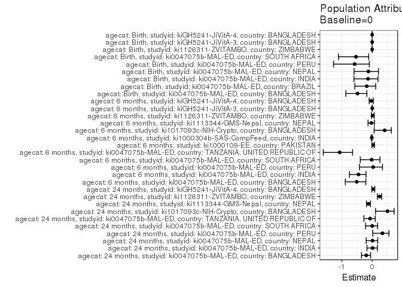

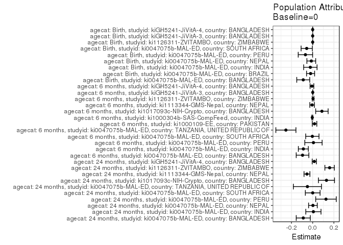

## Results Table

### Parameter: TSM

| agecat | studyid | country | intervention_level | baseline_level | estimate | ci_lower | ci_upper |
| --- | --- | --- | --- | --- | --- | --- | --- |
| Birth | ki0047075b-MAL-ED | BANGLADESH | 0 | NA | 0.2726123 | 0.1919150 | 0.3533095 |
| Birth | ki0047075b-MAL-ED | BANGLADESH | 1 | NA | 0.1721677 | 0.1161351 | 0.2282003 |
| Birth | ki0047075b-MAL-ED | BRAZIL | 0 | NA | 0.1296296 | 0.0661140 | 0.1931452 |
| Birth | ki0047075b-MAL-ED | BRAZIL | 1 | NA | 0.0843373 | 0.0243960 | 0.1442787 |
| Birth | ki0047075b-MAL-ED | INDIA | 0 | NA | 0.1830012 | 0.0982144 | 0.2677879 |
| Birth | ki0047075b-MAL-ED | INDIA | 1 | NA | 0.1464243 | 0.0847167 | 0.2081318 |
| Birth | ki0047075b-MAL-ED | NEPAL | 0 | NA | 0.1170213 | 0.0518509 | 0.1821917 |
| Birth | ki0047075b-MAL-ED | NEPAL | 1 | NA | 0.0886076 | 0.0257610 | 0.1514542 |
| Birth | ki0047075b-MAL-ED | PERU | 0 | NA | 0.1869266 | 0.1051440 | 0.2687091 |
| Birth | ki0047075b-MAL-ED | PERU | 1 | NA | 0.1040242 | 0.0633355 | 0.1447130 |
| Birth | ki0047075b-MAL-ED | SOUTH AFRICA | 0 | NA | 0.1616046 | 0.0885708 | 0.2346384 |
| Birth | ki0047075b-MAL-ED | SOUTH AFRICA | 1 | NA | 0.0801565 | 0.0380388 | 0.1222742 |
| Birth | ki1126311-ZVITAMBO | ZIMBABWE | 0 | NA | 0.1029133 | 0.0975480 | 0.1082786 |
| Birth | ki1126311-ZVITAMBO | ZIMBABWE | 1 | NA | 0.1028958 | 0.0975314 | 0.1082602 |
| Birth | kiGH5241-JiVitA-3 | BANGLADESH | 0 | NA | 0.3232683 | 0.3156084 | 0.3309282 |
| Birth | kiGH5241-JiVitA-3 | BANGLADESH | 1 | NA | 0.3228719 | 0.3152220 | 0.3305218 |
| Birth | kiGH5241-JiVitA-4 | BANGLADESH | 0 | NA | 0.3005119 | 0.2649383 | 0.3360855 |
| Birth | kiGH5241-JiVitA-4 | BANGLADESH | 1 | NA | 0.3004749 | 0.2649082 | 0.3360415 |
| 6 months | ki0047075b-MAL-ED | BANGLADESH | 0 | NA | 0.2833085 | 0.2034945 | 0.3631225 |
| 6 months | ki0047075b-MAL-ED | BANGLADESH | 1 | NA | 0.1910493 | 0.1325451 | 0.2495534 |
| 6 months | ki0047075b-MAL-ED | INDIA | 0 | NA | 0.2830099 | 0.2149569 | 0.3510629 |
| 6 months | ki0047075b-MAL-ED | INDIA | 1 | NA | 0.2153358 | 0.1564938 | 0.2741777 |
| 6 months | ki0047075b-MAL-ED | PERU | 0 | NA | 0.2124754 | 0.1176892 | 0.3072616 |
| 6 months | ki0047075b-MAL-ED | PERU | 1 | NA | 0.2223374 | 0.1650183 | 0.2796565 |
| 6 months | ki0047075b-MAL-ED | SOUTH AFRICA | 0 | NA | 0.1992454 | 0.1189673 | 0.2795234 |
| 6 months | ki0047075b-MAL-ED | SOUTH AFRICA | 1 | NA | 0.1939412 | 0.1319491 | 0.2559333 |
| 6 months | ki0047075b-MAL-ED | TANZANIA, UNITED REPUBLIC OF | 0 | NA | 0.4875758 | 0.3813039 | 0.5938477 |
| 6 months | ki0047075b-MAL-ED | TANZANIA, UNITED REPUBLIC OF | 1 | NA | 0.2182165 | 0.1629929 | 0.2734402 |
| 6 months | ki1000109-EE | PAKISTAN | 0 | NA | 0.5014809 | 0.4479820 | 0.5549798 |
| 6 months | ki1000109-EE | PAKISTAN | 1 | NA | 0.3239376 | 0.2584457 | 0.3894294 |
| 6 months | ki1000304b-SAS-CompFeed | INDIA | 0 | NA | 0.2882252 | 0.2712308 | 0.3052197 |
| 6 months | ki1000304b-SAS-CompFeed | INDIA | 1 | NA | 0.2561521 | 0.1945586 | 0.3177457 |
| 6 months | ki1017093c-NIH-Crypto | BANGLADESH | 0 | NA | 0.1227699 | 0.0624592 | 0.1830806 |
| 6 months | ki1017093c-NIH-Crypto | BANGLADESH | 1 | NA | 0.2227700 | 0.1901033 | 0.2554368 |
| 6 months | ki1113344-GMS-Nepal | NEPAL | 0 | NA | 0.2112600 | 0.1691194 | 0.2534006 |
| 6 months | ki1113344-GMS-Nepal | NEPAL | 1 | NA | 0.1366711 | 0.0826972 | 0.1906450 |
| 6 months | ki1126311-ZVITAMBO | ZIMBABWE | 0 | NA | 0.1638095 | 0.1524085 | 0.1752106 |
| 6 months | ki1126311-ZVITAMBO | ZIMBABWE | 1 | NA | 0.1617205 | 0.1511614 | 0.1722797 |
| 6 months | kiGH5241-JiVitA-3 | BANGLADESH | 0 | NA | 0.2508272 | 0.2426986 | 0.2589557 |
| 6 months | kiGH5241-JiVitA-3 | BANGLADESH | 1 | NA | 0.3999566 | 0.3523922 | 0.4475209 |
| 6 months | kiGH5241-JiVitA-4 | BANGLADESH | 0 | NA | 0.2598153 | 0.2370286 | 0.2826020 |
| 6 months | kiGH5241-JiVitA-4 | BANGLADESH | 1 | NA | 0.2444785 | 0.2279179 | 0.2610390 |
| 24 months | ki0047075b-MAL-ED | BANGLADESH | 0 | NA | 0.5484329 | 0.4579732 | 0.6388926 |
| 24 months | ki0047075b-MAL-ED | BANGLADESH | 1 | NA | 0.5614954 | 0.4828060 | 0.6401849 |
| 24 months | ki0047075b-MAL-ED | INDIA | 0 | NA | 0.4118759 | 0.3158327 | 0.5079191 |
| 24 months | ki0047075b-MAL-ED | INDIA | 1 | NA | 0.4230547 | 0.3414106 | 0.5046988 |
| 24 months | ki0047075b-MAL-ED | NEPAL | 0 | NA | 0.2125178 | 0.1470433 | 0.2779923 |
| 24 months | ki0047075b-MAL-ED | NEPAL | 1 | NA | 0.2688754 | 0.1917407 | 0.3460100 |
| 24 months | ki0047075b-MAL-ED | PERU | 0 | NA | 0.2427335 | 0.1342912 | 0.3511758 |
| 24 months | ki0047075b-MAL-ED | PERU | 1 | NA | 0.4122015 | 0.3338288 | 0.4905741 |
| 24 months | ki0047075b-MAL-ED | SOUTH AFRICA | 0 | NA | 0.3487307 | 0.2616231 | 0.4358383 |
| 24 months | ki0047075b-MAL-ED | SOUTH AFRICA | 1 | NA | 0.3964996 | 0.3202327 | 0.4727666 |
| 24 months | ki0047075b-MAL-ED | TANZANIA, UNITED REPUBLIC OF | 0 | NA | 0.7647059 | 0.6217907 | 0.9076211 |
| 24 months | ki0047075b-MAL-ED | TANZANIA, UNITED REPUBLIC OF | 1 | NA | 0.7055556 | 0.6388140 | 0.7722971 |
| 24 months | ki1017093c-NIH-Crypto | BANGLADESH | 0 | NA | 0.1267606 | 0.0492965 | 0.2042247 |
| 24 months | ki1017093c-NIH-Crypto | BANGLADESH | 1 | NA | 0.2776524 | 0.2359085 | 0.3193963 |
| 24 months | ki1113344-GMS-Nepal | NEPAL | 0 | NA | 0.5001176 | 0.4474778 | 0.5527574 |
| 24 months | ki1113344-GMS-Nepal | NEPAL | 1 | NA | 0.2495511 | 0.1861216 | 0.3129805 |
| 24 months | ki1126311-ZVITAMBO | ZIMBABWE | 0 | NA | 0.4894326 | 0.4261882 | 0.5526770 |
| 24 months | ki1126311-ZVITAMBO | ZIMBABWE | 1 | NA | 0.5594188 | 0.4998035 | 0.6190341 |
| 24 months | kiGH5241-JiVitA-4 | BANGLADESH | 0 | NA | 0.3779649 | 0.3523370 | 0.4035928 |
| 24 months | kiGH5241-JiVitA-4 | BANGLADESH | 1 | NA | 0.3921148 | 0.3717432 | 0.4124865 |

### Parameter: E(Y)

| agecat | studyid | country | intervention_level | baseline_level | estimate | ci_lower | ci_upper |
| --- | --- | --- | --- | --- | --- | --- | --- |
| Birth | ki0047075b-MAL-ED | BANGLADESH | NA | NA | 0.1835938 | 0.1360755 | 0.2311120 |
| Birth | ki0047075b-MAL-ED | BRAZIL | NA | NA | 0.1099476 | 0.0654669 | 0.1544284 |
| Birth | ki0047075b-MAL-ED | INDIA | NA | NA | 0.1609756 | 0.1105443 | 0.2114069 |
| Birth | ki0047075b-MAL-ED | NEPAL | NA | NA | 0.1040462 | 0.0584174 | 0.1496751 |
| Birth | ki0047075b-MAL-ED | PERU | NA | NA | 0.1184669 | 0.0810142 | 0.1559196 |
| Birth | ki0047075b-MAL-ED | SOUTH AFRICA | NA | NA | 0.1052632 | 0.0669131 | 0.1436132 |
| Birth | ki1126311-ZVITAMBO | ZIMBABWE | NA | NA | 0.1029304 | 0.0975643 | 0.1082966 |
| Birth | kiGH5241-JiVitA-3 | BANGLADESH | NA | NA | 0.3232690 | 0.3156091 | 0.3309289 |
| Birth | kiGH5241-JiVitA-4 | BANGLADESH | NA | NA | 0.3004866 | 0.2649179 | 0.3360553 |
| 6 months | ki0047075b-MAL-ED | BANGLADESH | NA | NA | 0.1875000 | 0.1380164 | 0.2369836 |
| 6 months | ki0047075b-MAL-ED | INDIA | NA | NA | 0.1949153 | 0.1442678 | 0.2455627 |
| 6 months | ki0047075b-MAL-ED | PERU | NA | NA | 0.2197802 | 0.1705687 | 0.2689917 |
| 6 months | ki0047075b-MAL-ED | SOUTH AFRICA | NA | NA | 0.1960000 | 0.1466935 | 0.2453065 |
| 6 months | ki0047075b-MAL-ED | TANZANIA, UNITED REPUBLIC OF | NA | NA | 0.2348178 | 0.1818480 | 0.2877876 |
| 6 months | ki1000109-EE | PAKISTAN | NA | NA | 0.5188172 | 0.4679751 | 0.5696593 |
| 6 months | ki1000304b-SAS-CompFeed | INDIA | NA | NA | 0.2844311 | 0.2666491 | 0.3022132 |
| 6 months | ki1017093c-NIH-Crypto | BANGLADESH | NA | NA | 0.2097902 | 0.1799252 | 0.2396552 |
| 6 months | ki1113344-GMS-Nepal | NEPAL | NA | NA | 0.2058824 | 0.1707553 | 0.2410094 |
| 6 months | ki1126311-ZVITAMBO | ZIMBABWE | NA | NA | 0.1674134 | 0.1588863 | 0.1759405 |
| 6 months | kiGH5241-JiVitA-3 | BANGLADESH | NA | NA | 0.2514221 | 0.2433018 | 0.2595424 |
| 6 months | kiGH5241-JiVitA-4 | BANGLADESH | NA | NA | 0.2528565 | 0.2387323 | 0.2669808 |
| 24 months | ki0047075b-MAL-ED | BANGLADESH | NA | NA | 0.4597156 | 0.3923103 | 0.5271210 |
| 24 months | ki0047075b-MAL-ED | INDIA | NA | NA | 0.4185022 | 0.3541865 | 0.4828179 |
| 24 months | ki0047075b-MAL-ED | NEPAL | NA | NA | 0.2149123 | 0.1614774 | 0.2683472 |
| 24 months | ki0047075b-MAL-ED | PERU | NA | NA | 0.3681592 | 0.3013164 | 0.4350020 |
| 24 months | ki0047075b-MAL-ED | SOUTH AFRICA | NA | NA | 0.3489362 | 0.2878666 | 0.4100058 |
| 24 months | ki0047075b-MAL-ED | TANZANIA, UNITED REPUBLIC OF | NA | NA | 0.7149533 | 0.6543278 | 0.7755787 |
| 24 months | ki1017093c-NIH-Crypto | BANGLADESH | NA | NA | 0.2568093 | 0.2190047 | 0.2946140 |
| 24 months | ki1113344-GMS-Nepal | NEPAL | NA | NA | 0.4461538 | 0.4004285 | 0.4918792 |
| 24 months | ki1126311-ZVITAMBO | ZIMBABWE | NA | NA | 0.6491228 | 0.6022363 | 0.6960093 |
| 24 months | kiGH5241-JiVitA-4 | BANGLADESH | NA | NA | 0.3930380 | 0.3758543 | 0.4102217 |

### Parameter: RR

| agecat | studyid | country | intervention_level | baseline_level | estimate | ci_lower | ci_upper |
| --- | --- | --- | --- | --- | --- | --- | --- |
| Birth | ki0047075b-MAL-ED | BANGLADESH | 0 | 0 | 1.0000000 | 1.0000000 | 1.0000000 |
| Birth | ki0047075b-MAL-ED | BANGLADESH | 1 | 0 | 0.6315478 | 0.4064690 | 0.9812620 |
| Birth | ki0047075b-MAL-ED | BRAZIL | 0 | 0 | 1.0000000 | 1.0000000 | 1.0000000 |
| Birth | ki0047075b-MAL-ED | BRAZIL | 1 | 0 | 0.6506024 | 0.2744139 | 1.5425001 |
| Birth | ki0047075b-MAL-ED | INDIA | 0 | 0 | 1.0000000 | 1.0000000 | 1.0000000 |
| Birth | ki0047075b-MAL-ED | INDIA | 1 | 0 | 0.8001274 | 0.4290076 | 1.4922903 |
| Birth | ki0047075b-MAL-ED | NEPAL | 0 | 0 | 1.0000000 | 1.0000000 | 1.0000000 |
| Birth | ki0047075b-MAL-ED | NEPAL | 1 | 0 | 0.7571922 | 0.3073032 | 1.8657146 |
| Birth | ki0047075b-MAL-ED | PERU | 0 | 0 | 1.0000000 | 1.0000000 | 1.0000000 |
| Birth | ki0047075b-MAL-ED | PERU | 1 | 0 | 0.5564979 | 0.3099890 | 0.9990351 |
| Birth | ki0047075b-MAL-ED | SOUTH AFRICA | 0 | 0 | 1.0000000 | 1.0000000 | 1.0000000 |
| Birth | ki0047075b-MAL-ED | SOUTH AFRICA | 1 | 0 | 0.4960039 | 0.2480445 | 0.9918378 |
| Birth | ki1126311-ZVITAMBO | ZIMBABWE | 0 | 0 | 1.0000000 | 1.0000000 | 1.0000000 |
| Birth | ki1126311-ZVITAMBO | ZIMBABWE | 1 | 0 | 0.9998300 | 0.9997257 | 0.9999344 |
| Birth | kiGH5241-JiVitA-3 | BANGLADESH | 0 | 0 | 1.0000000 | 1.0000000 | 1.0000000 |
| Birth | kiGH5241-JiVitA-3 | BANGLADESH | 1 | 0 | 0.9987739 | 0.9987389 | 0.9988088 |
| Birth | kiGH5241-JiVitA-4 | BANGLADESH | 0 | 0 | 1.0000000 | 1.0000000 | 1.0000000 |
| Birth | kiGH5241-JiVitA-4 | BANGLADESH | 1 | 0 | 0.9998768 | 0.9991942 | 1.0005598 |
| 6 months | ki0047075b-MAL-ED | BANGLADESH | 0 | 0 | 1.0000000 | 1.0000000 | 1.0000000 |
| 6 months | ki0047075b-MAL-ED | BANGLADESH | 1 | 0 | 0.6743506 | 0.4466328 | 1.0181715 |
| 6 months | ki0047075b-MAL-ED | INDIA | 0 | 0 | 1.0000000 | 1.0000000 | 1.0000000 |
| 6 months | ki0047075b-MAL-ED | INDIA | 1 | 0 | 0.7608771 | 0.5494944 | 1.0535756 |
| 6 months | ki0047075b-MAL-ED | PERU | 0 | 0 | 1.0000000 | 1.0000000 | 1.0000000 |
| 6 months | ki0047075b-MAL-ED | PERU | 1 | 0 | 1.0464148 | 0.6260267 | 1.7491011 |
| 6 months | ki0047075b-MAL-ED | SOUTH AFRICA | 0 | 0 | 1.0000000 | 1.0000000 | 1.0000000 |
| 6 months | ki0047075b-MAL-ED | SOUTH AFRICA | 1 | 0 | 0.9733788 | 0.5833663 | 1.6241362 |
| 6 months | ki0047075b-MAL-ED | TANZANIA, UNITED REPUBLIC OF | 0 | 0 | 1.0000000 | 1.0000000 | 1.0000000 |
| 6 months | ki0047075b-MAL-ED | TANZANIA, UNITED REPUBLIC OF | 1 | 0 | 0.4475541 | 0.3228775 | 0.6203734 |
| 6 months | ki1000109-EE | PAKISTAN | 0 | 0 | 1.0000000 | 1.0000000 | 1.0000000 |
| 6 months | ki1000109-EE | PAKISTAN | 1 | 0 | 0.6459619 | 0.5198353 | 0.8026904 |
| 6 months | ki1000304b-SAS-CompFeed | INDIA | 0 | 0 | 1.0000000 | 1.0000000 | 1.0000000 |
| 6 months | ki1000304b-SAS-CompFeed | INDIA | 1 | 0 | 0.8887221 | 0.7094336 | 1.1133204 |
| 6 months | ki1017093c-NIH-Crypto | BANGLADESH | 0 | 0 | 1.0000000 | 1.0000000 | 1.0000000 |
| 6 months | ki1017093c-NIH-Crypto | BANGLADESH | 1 | 0 | 1.8145329 | 1.0867598 | 3.0296756 |
| 6 months | ki1113344-GMS-Nepal | NEPAL | 0 | 0 | 1.0000000 | 1.0000000 | 1.0000000 |
| 6 months | ki1113344-GMS-Nepal | NEPAL | 1 | 0 | 0.6469332 | 0.4158098 | 1.0065239 |
| 6 months | ki1126311-ZVITAMBO | ZIMBABWE | 0 | 0 | 1.0000000 | 1.0000000 | 1.0000000 |
| 6 months | ki1126311-ZVITAMBO | ZIMBABWE | 1 | 0 | 0.9872473 | 0.9018625 | 1.0807159 |
| 6 months | kiGH5241-JiVitA-3 | BANGLADESH | 0 | 0 | 1.0000000 | 1.0000000 | 1.0000000 |
| 6 months | kiGH5241-JiVitA-3 | BANGLADESH | 1 | 0 | 1.5945503 | 1.4098293 | 1.8034743 |
| 6 months | kiGH5241-JiVitA-4 | BANGLADESH | 0 | 0 | 1.0000000 | 1.0000000 | 1.0000000 |
| 6 months | kiGH5241-JiVitA-4 | BANGLADESH | 1 | 0 | 0.9409704 | 0.8464390 | 1.0460591 |
| 24 months | ki0047075b-MAL-ED | BANGLADESH | 0 | 0 | 1.0000000 | 1.0000000 | 1.0000000 |
| 24 months | ki0047075b-MAL-ED | BANGLADESH | 1 | 0 | 1.0238179 | 0.8359798 | 1.2538618 |
| 24 months | ki0047075b-MAL-ED | INDIA | 0 | 0 | 1.0000000 | 1.0000000 | 1.0000000 |
| 24 months | ki0047075b-MAL-ED | INDIA | 1 | 0 | 1.0271413 | 0.7669321 | 1.3756357 |
| 24 months | ki0047075b-MAL-ED | NEPAL | 0 | 0 | 1.0000000 | 1.0000000 | 1.0000000 |
| 24 months | ki0047075b-MAL-ED | NEPAL | 1 | 0 | 1.2651899 | 0.8448535 | 1.8946547 |
| 24 months | ki0047075b-MAL-ED | PERU | 0 | 0 | 1.0000000 | 1.0000000 | 1.0000000 |
| 24 months | ki0047075b-MAL-ED | PERU | 1 | 0 | 1.6981649 | 1.0557273 | 2.7315426 |
| 24 months | ki0047075b-MAL-ED | SOUTH AFRICA | 0 | 0 | 1.0000000 | 1.0000000 | 1.0000000 |
| 24 months | ki0047075b-MAL-ED | SOUTH AFRICA | 1 | 0 | 1.1369795 | 0.8315200 | 1.5546497 |
| 24 months | ki0047075b-MAL-ED | TANZANIA, UNITED REPUBLIC OF | 0 | 0 | 1.0000000 | 1.0000000 | 1.0000000 |
| 24 months | ki0047075b-MAL-ED | TANZANIA, UNITED REPUBLIC OF | 1 | 0 | 0.9226496 | 0.7482854 | 1.1376438 |
| 24 months | ki1017093c-NIH-Crypto | BANGLADESH | 0 | 0 | 1.0000000 | 1.0000000 | 1.0000000 |
| 24 months | ki1017093c-NIH-Crypto | BANGLADESH | 1 | 0 | 2.1903687 | 1.1673562 | 4.1098980 |
| 24 months | ki1113344-GMS-Nepal | NEPAL | 0 | 0 | 1.0000000 | 1.0000000 | 1.0000000 |
| 24 months | ki1113344-GMS-Nepal | NEPAL | 1 | 0 | 0.4989848 | 0.3796447 | 0.6558389 |
| 24 months | ki1126311-ZVITAMBO | ZIMBABWE | 0 | 0 | 1.0000000 | 1.0000000 | 1.0000000 |
| 24 months | ki1126311-ZVITAMBO | ZIMBABWE | 1 | 0 | 1.1429947 | 0.9769824 | 1.3372163 |
| 24 months | kiGH5241-JiVitA-4 | BANGLADESH | 0 | 0 | 1.0000000 | 1.0000000 | 1.0000000 |
| 24 months | kiGH5241-JiVitA-4 | BANGLADESH | 1 | 0 | 1.0374373 | 0.9586265 | 1.1227273 |

### Parameter: PAR

| agecat | studyid | country | intervention_level | baseline_level | estimate | ci_lower | ci_upper |
| --- | --- | --- | --- | --- | --- | --- | --- |
| Birth | ki0047075b-MAL-ED | BANGLADESH | 0 | NA | -0.0890185 | -0.1501785 | -0.0278586 |
| Birth | ki0047075b-MAL-ED | BRAZIL | 0 | NA | -0.0196820 | -0.0577674 | 0.0184034 |
| Birth | ki0047075b-MAL-ED | INDIA | 0 | NA | -0.0220256 | -0.0852070 | 0.0411559 |
| Birth | ki0047075b-MAL-ED | NEPAL | 0 | NA | -0.0129750 | -0.0543724 | 0.0284223 |
| Birth | ki0047075b-MAL-ED | PERU | 0 | NA | -0.0684597 | -0.1363679 | -0.0005515 |
| Birth | ki0047075b-MAL-ED | SOUTH AFRICA | 0 | NA | -0.0563415 | -0.1094593 | -0.0032236 |
| Birth | ki1126311-ZVITAMBO | ZIMBABWE | 0 | NA | 0.0000171 | 0.0000116 | 0.0000227 |
| Birth | kiGH5241-JiVitA-3 | BANGLADESH | 0 | NA | 0.0000007 | 0.0000004 | 0.0000010 |
| Birth | kiGH5241-JiVitA-4 | BANGLADESH | 0 | NA | -0.0000253 | -0.0001661 | 0.0001155 |
| 6 months | ki0047075b-MAL-ED | BANGLADESH | 0 | NA | -0.0958085 | -0.1553261 | -0.0362909 |
| 6 months | ki0047075b-MAL-ED | INDIA | 0 | NA | -0.0880947 | -0.1350909 | -0.0410984 |
| 6 months | ki0047075b-MAL-ED | PERU | 0 | NA | 0.0073048 | -0.0744082 | 0.0890178 |
| 6 months | ki0047075b-MAL-ED | SOUTH AFRICA | 0 | NA | -0.0032454 | -0.0659739 | 0.0594831 |
| 6 months | ki0047075b-MAL-ED | TANZANIA, UNITED REPUBLIC OF | 0 | NA | -0.2527580 | -0.3474003 | -0.1581157 |
| 6 months | ki1000109-EE | PAKISTAN | 0 | NA | 0.0173363 | -0.0041515 | 0.0388241 |
| 6 months | ki1000304b-SAS-CompFeed | INDIA | 0 | NA | -0.0037941 | -0.0085903 | 0.0010021 |
| 6 months | ki1017093c-NIH-Crypto | BANGLADESH | 0 | NA | 0.0870203 | 0.0283713 | 0.1456693 |
| 6 months | ki1113344-GMS-Nepal | NEPAL | 0 | NA | -0.0053777 | -0.0268980 | 0.0161427 |
| 6 months | ki1126311-ZVITAMBO | ZIMBABWE | 0 | NA | 0.0036039 | -0.0043152 | 0.0115230 |
| 6 months | kiGH5241-JiVitA-3 | BANGLADESH | 0 | NA | 0.0005949 | 0.0002111 | 0.0009787 |
| 6 months | kiGH5241-JiVitA-4 | BANGLADESH | 0 | NA | -0.0069587 | -0.0244752 | 0.0105578 |
| 24 months | ki0047075b-MAL-ED | BANGLADESH | 0 | NA | -0.0887172 | -0.1551194 | -0.0223151 |
| 24 months | ki0047075b-MAL-ED | INDIA | 0 | NA | 0.0066263 | -0.0651974 | 0.0784501 |
| 24 months | ki0047075b-MAL-ED | NEPAL | 0 | NA | 0.0023945 | -0.0385075 | 0.0432965 |
| 24 months | ki0047075b-MAL-ED | PERU | 0 | NA | 0.1254257 | 0.0284873 | 0.2223641 |
| 24 months | ki0047075b-MAL-ED | SOUTH AFRICA | 0 | NA | 0.0002055 | -0.0692896 | 0.0697006 |
| 24 months | ki0047075b-MAL-ED | TANZANIA, UNITED REPUBLIC OF | 0 | NA | -0.0497526 | -0.1824557 | 0.0829504 |
| 24 months | ki1017093c-NIH-Crypto | BANGLADESH | 0 | NA | 0.1300488 | 0.0540744 | 0.2060231 |
| 24 months | ki1113344-GMS-Nepal | NEPAL | 0 | NA | -0.0539637 | -0.0817166 | -0.0262109 |
| 24 months | ki1126311-ZVITAMBO | ZIMBABWE | 0 | NA | 0.1596902 | 0.1151402 | 0.2042403 |
| 24 months | kiGH5241-JiVitA-4 | BANGLADESH | 0 | NA | 0.0150732 | -0.0046739 | 0.0348202 |

### Parameter: PAF

| agecat | studyid | country | intervention_level | baseline_level | estimate | ci_lower | ci_upper |
| --- | --- | --- | --- | --- | --- | --- | --- |
| Birth | ki0047075b-MAL-ED | BANGLADESH | 0 | NA | -0.4848669 | -0.8738061 | -0.1766583 |
| Birth | ki0047075b-MAL-ED | BRAZIL | 0 | NA | -0.1790123 | -0.5744279 | 0.1170951 |
| Birth | ki0047075b-MAL-ED | INDIA | 0 | NA | -0.1368254 | -0.6026820 | 0.1936191 |
| Birth | ki0047075b-MAL-ED | NEPAL | 0 | NA | -0.1247045 | -0.5980788 | 0.2084494 |
| Birth | ki0047075b-MAL-ED | PERU | 0 | NA | -0.5778801 | -1.2760986 | -0.0938479 |
| Birth | ki0047075b-MAL-ED | SOUTH AFRICA | 0 | NA | -0.5352438 | -1.1156178 | -0.1140829 |
| Birth | ki1126311-ZVITAMBO | ZIMBABWE | 0 | NA | 0.0001664 | 0.0001132 | 0.0002196 |
| Birth | kiGH5241-JiVitA-3 | BANGLADESH | 0 | NA | 0.0000023 | 0.0000014 | 0.0000032 |
| Birth | kiGH5241-JiVitA-4 | BANGLADESH | 0 | NA | -0.0000841 | -0.0005526 | 0.0003841 |
| 6 months | ki0047075b-MAL-ED | BANGLADESH | 0 | NA | -0.5109786 | -0.8882638 | -0.2090770 |
| 6 months | ki0047075b-MAL-ED | INDIA | 0 | NA | -0.4519639 | -0.7503090 | -0.2044726 |
| 6 months | ki0047075b-MAL-ED | PERU | 0 | NA | 0.0332370 | -0.4201208 | 0.3418653 |
| 6 months | ki0047075b-MAL-ED | SOUTH AFRICA | 0 | NA | -0.0165580 | -0.3926766 | 0.2579826 |
| 6 months | ki0047075b-MAL-ED | TANZANIA, UNITED REPUBLIC OF | 0 | NA | -1.0764005 | -1.6166305 | -0.6477064 |
| 6 months | ki1000109-EE | PAKISTAN | 0 | NA | 0.0334151 | -0.0087482 | 0.0738161 |
| 6 months | ki1000304b-SAS-CompFeed | INDIA | 0 | NA | -0.0133392 | -0.0306121 | 0.0036442 |
| 6 months | ki1017093c-NIH-Crypto | BANGLADESH | 0 | NA | 0.4147968 | 0.0652863 | 0.6336175 |
| 6 months | ki1113344-GMS-Nepal | NEPAL | 0 | NA | -0.0261200 | -0.1360048 | 0.0731357 |
| 6 months | ki1126311-ZVITAMBO | ZIMBABWE | 0 | NA | 0.0215269 | -0.0269050 | 0.0676746 |
| 6 months | kiGH5241-JiVitA-3 | BANGLADESH | 0 | NA | 0.0023663 | 0.0008369 | 0.0038934 |
| 6 months | kiGH5241-JiVitA-4 | BANGLADESH | 0 | NA | -0.0275205 | -0.0991589 | 0.0394488 |
| 24 months | ki0047075b-MAL-ED | BANGLADESH | 0 | NA | -0.1929829 | -0.3523177 | -0.0524215 |
| 24 months | ki0047075b-MAL-ED | INDIA | 0 | NA | 0.0158334 | -0.1716587 | 0.1733226 |
| 24 months | ki0047075b-MAL-ED | NEPAL | 0 | NA | 0.0111417 | -0.1985653 | 0.1841574 |
| 24 months | ki0047075b-MAL-ED | PERU | 0 | NA | 0.3406834 | 0.0212057 | 0.5558838 |
| 24 months | ki0047075b-MAL-ED | SOUTH AFRICA | 0 | NA | 0.0005889 | -0.2197907 | 0.1811524 |
| 24 months | ki0047075b-MAL-ED | TANZANIA, UNITED REPUBLIC OF | 0 | NA | -0.0695886 | -0.2727644 | 0.1011535 |
| 24 months | ki1017093c-NIH-Crypto | BANGLADESH | 0 | NA | 0.5064020 | 0.1125047 | 0.7254758 |
| 24 months | ki1113344-GMS-Nepal | NEPAL | 0 | NA | -0.1209532 | -0.1866651 | -0.0588802 |
| 24 months | ki1126311-ZVITAMBO | ZIMBABWE | 0 | NA | 0.2460093 | 0.1725080 | 0.3129819 |
| 24 months | kiGH5241-JiVitA-4 | BANGLADESH | 0 | NA | 0.0383505 | -0.0131827 | 0.0872625 |